# First interim analysis for SII Study 2

### Introduction

Research on person perception has revealed that people tend to attribute others’ behavior to stable person characteristics, even if it can just as well be explained by reasons such as situational factors or mental states. This tendency is known as the correspondence bias (Gilbert & Malone, 1995) and may play an important role in the domain of political polarization. Specifically, people may attribute each other’s politically relevant behaviors to stable ideological dispositions (such as leftist, conservative, racist, or feminist), while neglecting potential other causes and thereby impeding mutual understanding. To investigate the role of the correspondence bias in political polarization, we examine whether spontaneous ideological inferences are reduced when behaviors are accompanied by information on relatively sufficient reasons for the behavior. We thus extend previous research on spontaneous trait inferences (STI, Winter & Uleman, 1984) and the correspondence bias to spontaneous inferences of ideological dispositions.

### Sample Characteristics

For the first interim analysis we collected data from a total of N = 125 participants. Following our pre-registered exclusion criteria, we excluded 5 participants whose average correct response times were slower than two standard deviations over the sample mean, 1 who rated their own data to be unfit for analysis, and 1 who did not give informed consent. This resulted in a sample of N = 118 participants (63 female, 53 male, 1 other; average age M = 27.3 years, SD = 7.5, ranging from 18 to 66). Participants were recruited via the online platform Prolific (www.prolific.co) and received monetary compensation of 4.50 GBP for completing the 30-minute study. An additional 18 people started the experiment on prolific but either returned their submission, timed-out, or only partially completed the experiment due to technical issues.

On average, participants reported to be rather left leaning (M = 3.9, SD = 1.4 on a scale from 1 = left to 10 = right), rather interested in politics (M = 5.9, SD = 2.1, on a scale ranging from 1 = not at all to 10 = very strongly), and moderately satisfied with the German political system (M = 2.4, SD = 0.5, on a scale ranging from 1 = satisfied to 4 = dissatisfied).

### Preregistered hypothesis

```r
# Find extreme outliers
rt_long_2f <- rt_long_2f %>%
    group_by(probe_type, reason_type) %>%
    mutate(is_extreme = is_extreme(rt_M2SD_log)) %>%
    ungroup()
# Anova
# anova_test function automatically applies sphericity correction
# (Greenhouse-Geisser) if Mauchly's test indicates a violation
m1 <- anova_test(
    data = filter(rt_long_2f, is_extreme == FALSE),
    dv = rt_M2SD_log, wid = subject_id, effect.size = "pes",
    within = c(probe_type, reason_type)
)
# Descriptives
desc_2f <- rt_long_2f %>%
    group_by(probe_type, reason_type) %>%
    get_summary_stats(rt_M2SD_none, type = "mean_sd")
```

The main effect for probe type was significant at the pre-registered alpha boundary of = .0002, F(1, 117) = 200.777, p < .001, $\eta_{p}^{2}$ = .63. There was no significant interaction between probe type and reason type, F(1, 117) = 1.143, p = .287, $\eta_{p}^{2}$ = .01.

#### Outlier detection 2f

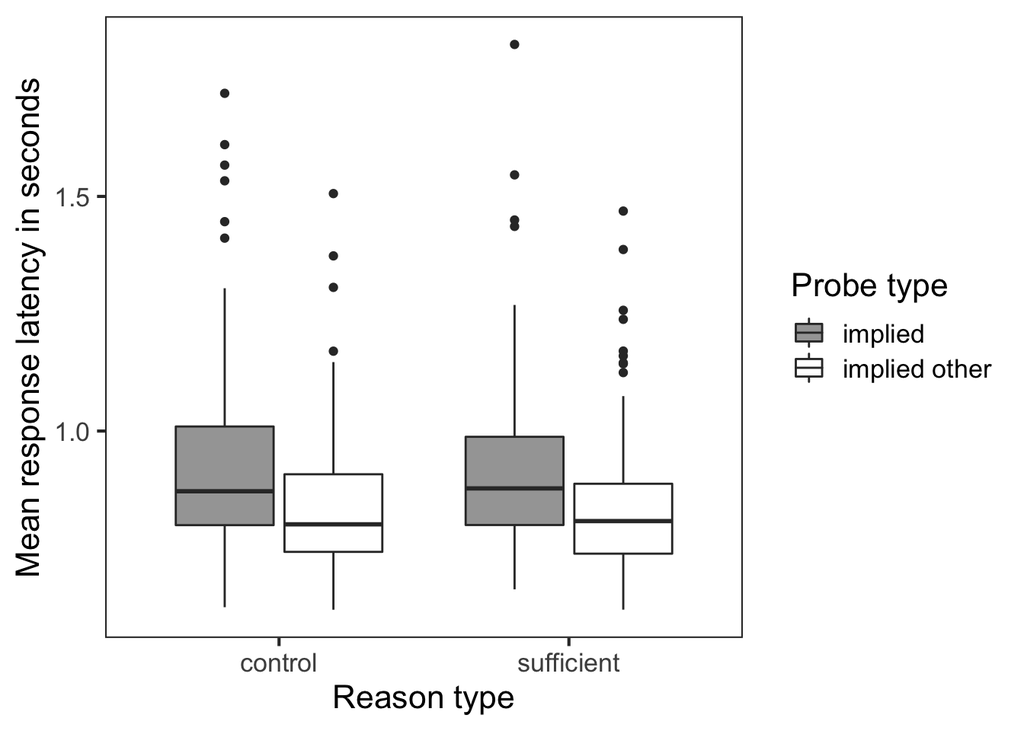

```r
filter(rt_long_2f, is_extreme == FALSE) %>%
    ggplot(aes(reason_type, rt_M2SD_none, fill = probe_type)) +
    geom_boxplot() +
    labs(x = "Reason type", y = "Mean response latency in seconds", fill = "Probe type") + # nolint
    scale_fill_manual(values = c("#a5a5a5", "#ffffff")) +
    theme_bw(base_size = 16) +
    theme(panel.grid.major = element_blank(), panel.grid.minor = element_blank()) + # nolint
    geom_point(
        # Replace all non-outlier values by NA
        data = mutate(rt_long_2f, rt_M2SD_none = replace(rt_M2SD_none, is_extreme == FALSE, NA)), # nolint
        position = position_dodge(width = 0.75), shape = 4,
        size = 4, show.legend = FALSE)
```

#### QQ-Plot

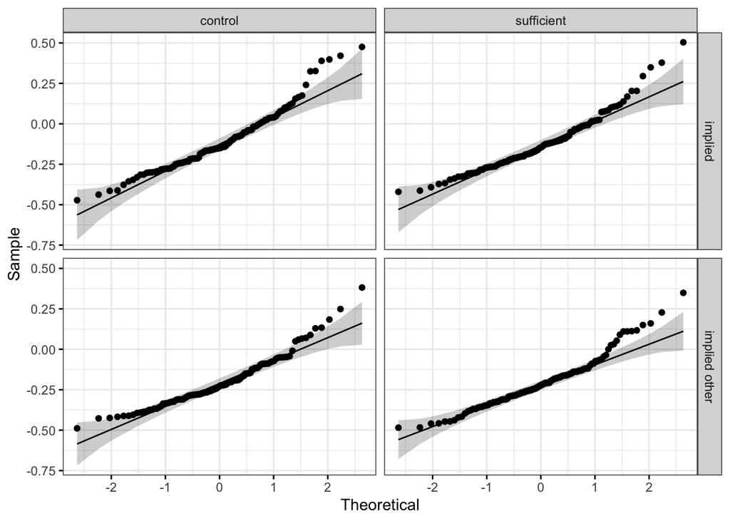

```r
# Visual inspection of normality
# Data appears moderately non-normal
ggqqplot(rt_long_2f,
    "rt_M2SD_log", ggtheme = theme_bw()) +
    facet_grid(probe_type ~ reason_type, labeller = "label_value")
```

#### ANOVA

```r
knitr::kable(m1, format = "markdown")
```

| Effect | DFn | DFd | F | p | p<.05 | pes |
| --- | --- | --- | --- | --- | --- | --- |
| probe_type | 1 | 117 | 200.777 | 0.000 | * | 0.632 |
| reason_type | 1 | 117 | 1.510 | 0.222 |  | 0.013 |
| probe_type:reason_type | 1 | 117 | 1.143 | 0.287 |  | 0.010 |

#### Descriptives

```r
knitr::kable(desc_2f, format = "markdown")
```

| probe_type | reason_type | variable | n | mean | sd |
| --- | --- | --- | --- | --- | --- |
| implied | control | rt_M2SD_none | 118 | 0.929 | 0.198 |
| implied | sufficient | rt_M2SD_none | 118 | 0.914 | 0.181 |
| implied other | control | rt_M2SD_none | 118 | 0.840 | 0.146 |
| implied other | sufficient | rt_M2SD_none | 118 | 0.839 | 0.151 |

#### Visualization

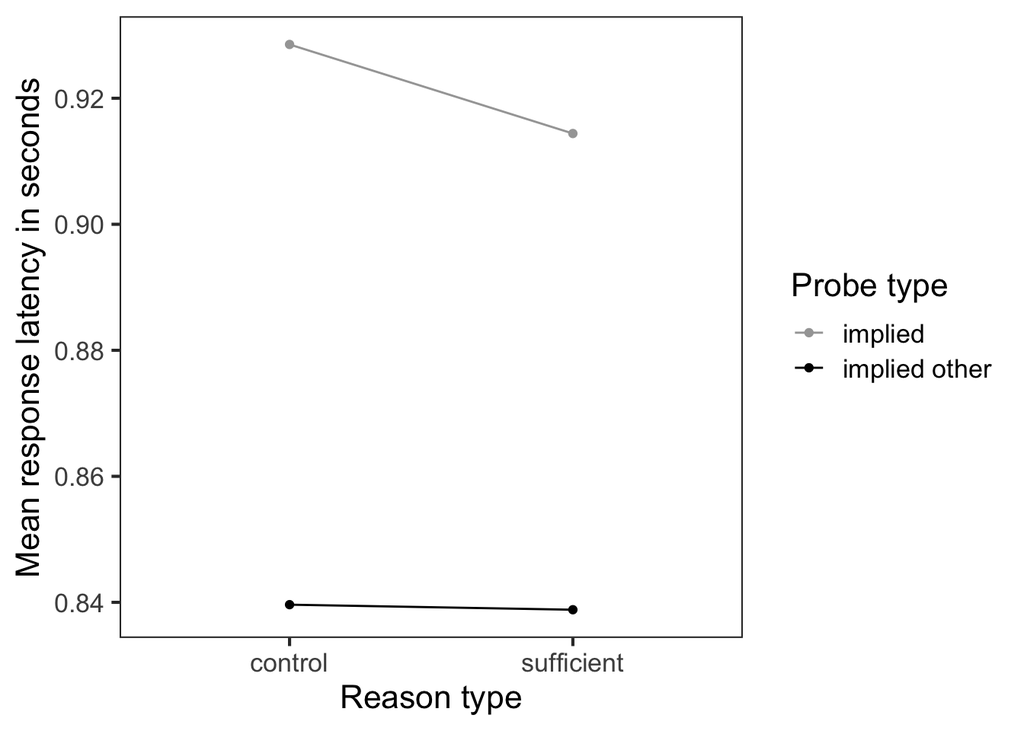

```r
rt_long_2f %>%
    ggplot() +
    aes(reason_type, rt_M2SD_none, color = probe_type, group = probe_type) +
    labs(x = "Reason type", y = "Mean response latency in seconds", color = "Probe type") + # nolint
    scale_color_manual(values = c("#a5a5a5", "#000000")) +
    stat_summary(fun = mean, geom = "point") +
    stat_summary(fun = mean, geom = "line") +
    theme_bw(base_size = 16) +
    theme(panel.grid.major = element_blank(), panel.grid.minor = element_blank()) # nolint
```

#### Post-hoc tests

```r
p1 <- rt_long_2f %>%
  group_by(reason_type) %>%
  pairwise_t_test(
    rt_M2SD_log ~ probe_type, paired = TRUE,
    p.adjust.method = "bonferroni"
    )
knitr::kable(p1, format = "markdown")
```

| reason_type | .y. | group1 | group2 | n1 | n2 | statistic | df | p | p.adj | p.adj.signif |
| --- | --- | --- | --- | --- | --- | --- | --- | --- | --- | --- |
| control | rt_M2SD_log | implied | implied other | 118 | 118 | 10.39383 | 117 | 0 | 0 | **** |
| sufficient | rt_M2SD_log | implied | implied other | 118 | 118 | 12.33906 | 117 | 0 | 0 | **** |

#### Multiverse analysis

Because there are no conventions regarding outlier correction and transformations, we follow a recommendation by Krieglmeyer & Deutsch (2010) and employ a multiverse analysis using different cut-off criteria (no cut-off, 2500 ms, 2000 ms, and 1500 ms) and transformations (no transformation, a log-transformation, and an inverse transformation) and report each combination’s effects on the results.

```r
# Select all variables containing reaction time means
rt_multi <- rt_long_2f %>%
    select(subject_id, probe_type, reason_type, starts_with("rt")) %>%
    pivot_longer(
        cols = starts_with("rt"),
        names_to = c(NA, "cutoff", "trans"),
        values_to = "rt",
        names_sep = "_")
# Loop over all combinations of cutoffs and transformations
multi <- multi_h1 <- multi_h2 <- data.frame(
    cutoff = rep(c("none", "M2SD", "f25", "f20", "f15"), 3),
    transformation = c(rep("none", 5), rep("log", 5), rep("inv", 5)))
for (c in seq(nrow(multi))) {
    # Filter data using c-th cutoff and transformation
    rt_multi_c <- rt_multi %>%
        filter(cutoff == multi$cutoff[c] & trans == multi$transformation[c])
    # Calculate test and effect size
    mv1 <- anova_test(
        data = rt_multi_c,
        dv = rt, wid = subject_id, effect.size = "pes",
        within = c(probe_type, reason_type)
    )
    # Save test statistics for h1
    multi_h1$DFn[c] <- mv1$DFn[1]
    multi_h1$DFd[c] <- mv1$DFc[1]
    multi_h1$F[c] <- mv1$F[1]
    multi_h1$p[c] <- format_p(mv1$p[1], num_only = TRUE)
    multi_h1$pes[c] <- format_apa(mv1$pes[1], leading_zero = FALSE)

    # Save test statistics for h2
    multi_h2$DFn[c] <- mv1$DFn[3]
    multi_h2$DFd[c] <- mv1$DFc[3]
    multi_h2$F[c] <- mv1$F[3]
    multi_h2$p[c] <- format_p(mv1$p[3], num_only = TRUE)
    multi_h2$pes[c] <- format_apa(mv1$pes[3], leading_zero = FALSE)
}
# Print multiverse table
knitr::kable(multi_h1, format = "markdown")
```

| cutoff | transformation | DFn | F | p | pes |
| --- | --- | --- | --- | --- | --- |
| none | none | 1 | 34.852 | <.001 | .23 |
| M2SD | none | 1 | 132.578 | <.001 | .53 |
| f25 | none | 1 | 212.906 | <.001 | .64 |
| f20 | none | 1 | 202.994 | <.001 | .63 |
| f15 | none | 1 | 230.484 | <.001 | .66 |
| none | log | 1 | 228.458 | <.001 | .66 |
| M2SD | log | 1 | 200.777 | <.001 | .63 |
| f25 | log | 1 | 273.063 | <.001 | .7 |
| f20 | log | 1 | 257.698 | <.001 | .69 |
| f15 | log | 1 | 255.145 | <.001 | .69 |
| none | inv | 1 | 259.941 | <.001 | .69 |
| M2SD | inv | 1 | 209.956 | <.001 | .64 |
| f25 | inv | 1 | 262.001 | <.001 | .69 |
| f20 | inv | 1 | 245.573 | <.001 | .68 |
| f15 | inv | 1 | 217.435 | <.001 | .65 |

```r
knitr::kable(multi_h2, format = "markdown")
```

| cutoff | transformation | DFn | F | p | pes |
| --- | --- | --- | --- | --- | --- |
| none | none | 1 | 1.056 | .306 | .009 |
| M2SD | none | 1 | 1.878 | .173 | .016 |
| f25 | none | 1 | 0.525 | .47 | .004 |
| f20 | none | 1 | 0.264 | .608 | .002 |
| f15 | none | 1 | 0.002 | .96 | .00002 |
| none | log | 1 | 0.036 | .851 | .0003 |
| M2SD | log | 1 | 1.143 | .287 | .01 |
| f25 | log | 1 | 0.232 | .631 | .002 |
| f20 | log | 1 | 0.122 | .728 | .001 |
| f15 | log | 1 | 0.014 | .906 | .0001 |
| none | inv | 1 | 0.037 | .848 | .0003 |
| M2SD | inv | 1 | 0.875 | .351 | .007 |
| f25 | inv | 1 | 0.240 | .625 | .002 |
| f20 | inv | 1 | 0.174 | .677 | .001 |
| f15 | inv | 1 | 0.010 | .92 | .00009 |

```r
# Save multiverse table as csv
# write.csv(multi_h1, here::here("Analysis/multiverse_h2.csv"))
```

### Exploratory error rate analysis

```r
# Prepare data
er_long_2f <- rt %>%
    group_by(subject_id, probe_type, reason_type) %>%
    summarize(correct_responses = n()) %>%
    mutate(er = (12 - correct_responses) / 12) %>%
    select(-correct_responses)

# Identify outliers
er_long_2f <- er_long_2f %>%
    group_by(probe_type, reason_type) %>%
    mutate(is_extreme = is_extreme(er)) %>%
    ungroup()

# Anova
# anova_test function automatically applies sphericity correction
# (Greenhouse-Geisser) if Mauchly's test indicates a violation
er_m1 <- anova_test(
    data = filter(er_long_2f, is_extreme == FALSE),
    dv = er, wid = subject_id, effect.size = "pes",
    within = c(probe_type, reason_type)
)
# Descriptives
er_desc_2f <- er_long_2f %>%
    group_by(probe_type, reason_type) %>%
    get_summary_stats(er, type = "mean_sd")
```

The main effect for probe type was significant, F(1, 79) = 88.673, p < .001, $\eta_{p}^{2}$ = .53. There was no significant interaction between probe type and reason type, F(1, 79) = 0.03, p = .862, $\eta_{p}^{2}$ = .0004.

#### Outlier detection 2f

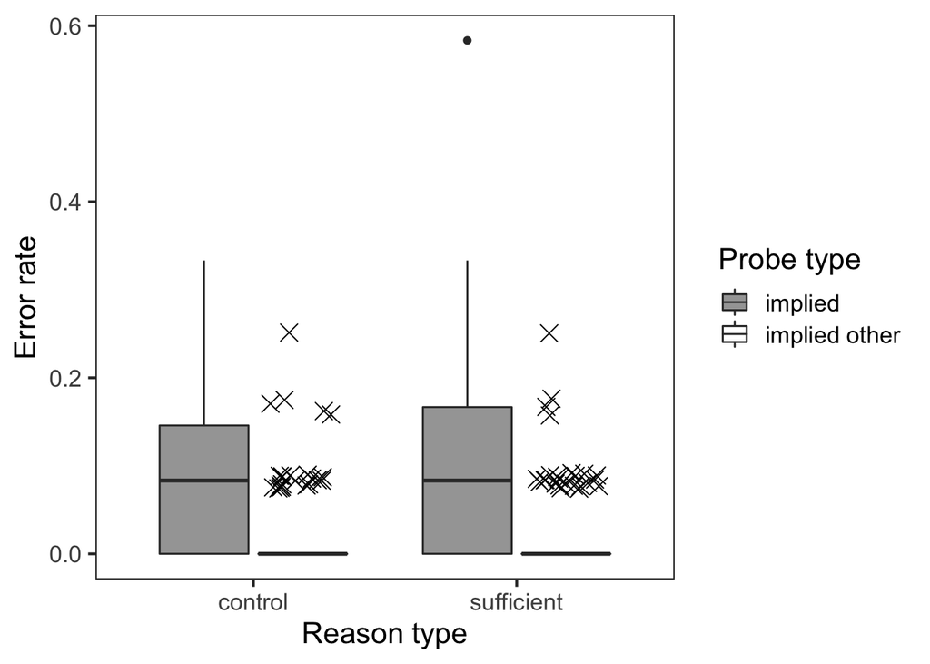

```r
filter(er_long_2f, is_extreme == FALSE) %>%
    ggplot(aes(reason_type, er, fill = probe_type)) +
    geom_boxplot(aes(fill = probe_type)) +
    labs(x = "Reason type", y = "Error rate", fill = "Probe type") + # nolint
    scale_fill_manual(values = c("#a5a5a5", "#ffffff")) +
    theme_bw(base_size = 16) +
    theme(panel.grid.major = element_blank(), panel.grid.minor = element_blank()) + # nolint
    geom_point(
        # Replace all non-outlier values by NA
        data = mutate(er_long_2f, er = replace(er, is_extreme == FALSE, NA)), # nolint
        position = position_jitterdodge(0.5, 0.01, 0.75, 3),
        shape = 4, size = 4, show.legend = FALSE)
```

#### QQ-Plot

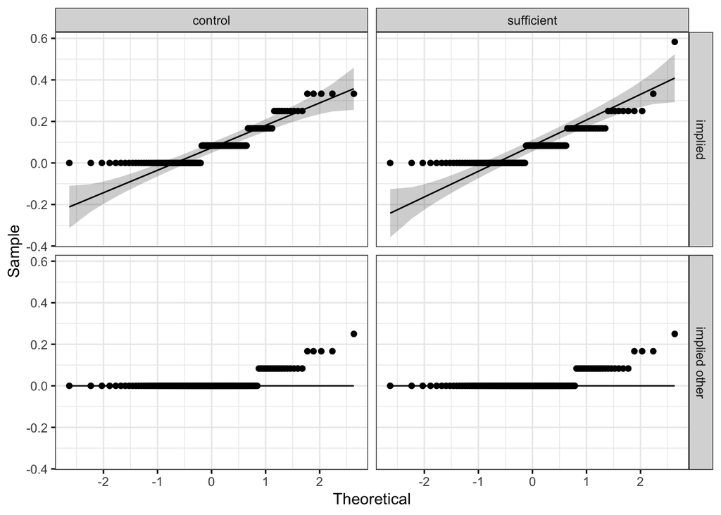

```r
# Visual inspection of normality
# Data appears moderately non-normal
ggqqplot(er_long_2f,
    "er", ggtheme = theme_bw()) +
    facet_grid(probe_type ~ reason_type, labeller = "label_value")
```

#### ANOVA

```r
knitr::kable(er_m1, format = "markdown")
```

| Effect | DFn | DFd | F | p | p<.05 | pes |
| --- | --- | --- | --- | --- | --- | --- |
| probe_type | 1 | 79 | 88.673 | 0.000 | * | 0.529000 |
| reason_type | 1 | 79 | 0.030 | 0.862 |  | 0.000385 |
| probe_type:reason_type | 1 | 79 | 0.030 | 0.862 |  | 0.000385 |

#### Descriptives

```r
knitr::kable(er_desc_2f, format = "markdown")
```

| probe_type | reason_type | variable | n | mean | sd |
| --- | --- | --- | --- | --- | --- |
| implied | control | er | 118 | 0.083 | 0.094 |
| implied | sufficient | er | 118 | 0.078 | 0.095 |
| implied other | control | er | 118 | 0.020 | 0.046 |
| implied other | sufficient | er | 118 | 0.021 | 0.045 |

#### Visualization

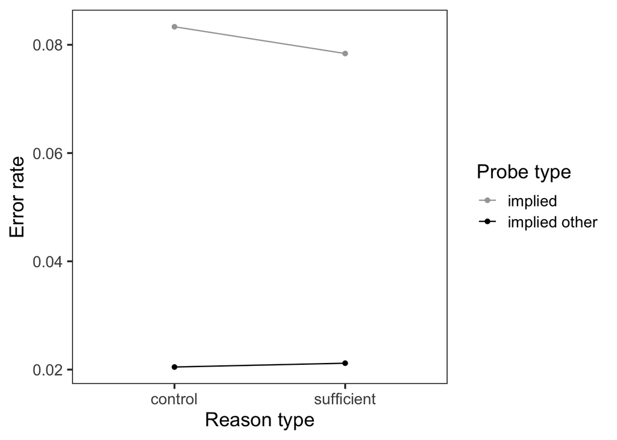

```r
er_long_2f %>%
    ggplot() +
    aes(reason_type, er, color = probe_type, group = probe_type) +
    labs(x = "Reason type", y = "Error rate", color = "Probe type") +
    scale_color_manual(values = c("#a5a5a5", "#000000")) +
    stat_summary(fun = mean, geom = "point") +
    stat_summary(fun = mean, geom = "line") +
    theme_bw(base_size = 16) +
    theme(panel.grid.major = element_blank(), panel.grid.minor = element_blank()) # nolint
```

#### Post-hoc tests

```r
er_p1 <- er_long_2f %>%
  group_by(reason_type) %>%
  pairwise_t_test(
    er ~ probe_type, paired = TRUE,
    p.adjust.method = "bonferroni"
    )
knitr::kable(er_p1, format = "markdown")
```

| reason_type | .y. | group1 | group2 | n1 | n2 | statistic | df | p | p.adj | p.adj.signif |
| --- | --- | --- | --- | --- | --- | --- | --- | --- | --- | --- |
| control | er | implied | implied other | 118 | 118 | 7.899068 | 117 | 0 | 0 | **** |
| sufficient | er | implied | implied other | 118 | 118 | 7.090431 | 117 | 0 | 0 | **** |

### Exploratory analysis of order of presentation

```r
# Find extreme outliers
rt_long_3f <- rt_long_3f %>%
    group_by(probe_type, reason_type, item_order) %>%
    mutate(is_extreme = is_extreme(rt_M2SD_log)) %>%
    ungroup()
# Run ANOVA
m2 <- anova_test(
    data = filter(rt_long_3f, is_extreme == FALSE),
    dv = rt_M2SD_log, wid = subject_id, effect.size = "pes",
    within = c(probe_type, reason_type, item_order)
)
```

The order of presentation of the behaviors and reasons was randomized for each participant, with half of the items beginning with the behavior and the other half beginning with the reason. We ran analyses to test whether the interaction between probe type and reason type might only be found when the reason is presented first. We excluded 1 extreme outliers. Upon visual inspection the distributions in the different conditions did not seem severely non-normal. We therefore performed a three-way repeated-measures ANOVA to evaluate the effect of probe type, reason type, and order of presentation on the mean response latencies.

#### Outlier detection 3f

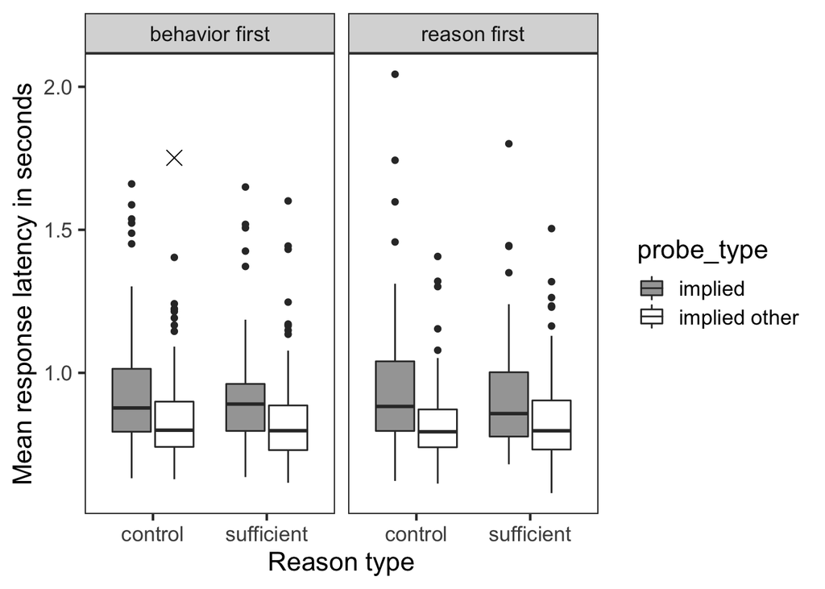

```r
filter(rt_long_3f, is_extreme == FALSE) %>%
    ggplot(aes(reason_type, rt_M2SD_none, fill = probe_type)) + # nolint
    geom_boxplot() +
    facet_wrap(. ~ item_order, labeller = "label_value") +
    labs(x = "Reason type", y = "Mean response latency in seconds", group = "Probe type") + # nolint
    scale_fill_manual(values = c("#a5a5a5", "#ffffff")) +
    theme_bw(base_size = 16) +
    theme(panel.grid.major = element_blank(), panel.grid.minor = element_blank()) + # nolint
    geom_point(
        # Replace all non-outlier values by NA
        data = mutate(rt_long_3f, rt_M2SD_none = replace(rt_M2SD_none, is_extreme == FALSE, NA)), # nolint
        position = position_dodge(width = 0.75), shape = 4,
        size = 4, show.legend = FALSE)
```

#### QQ-Plot

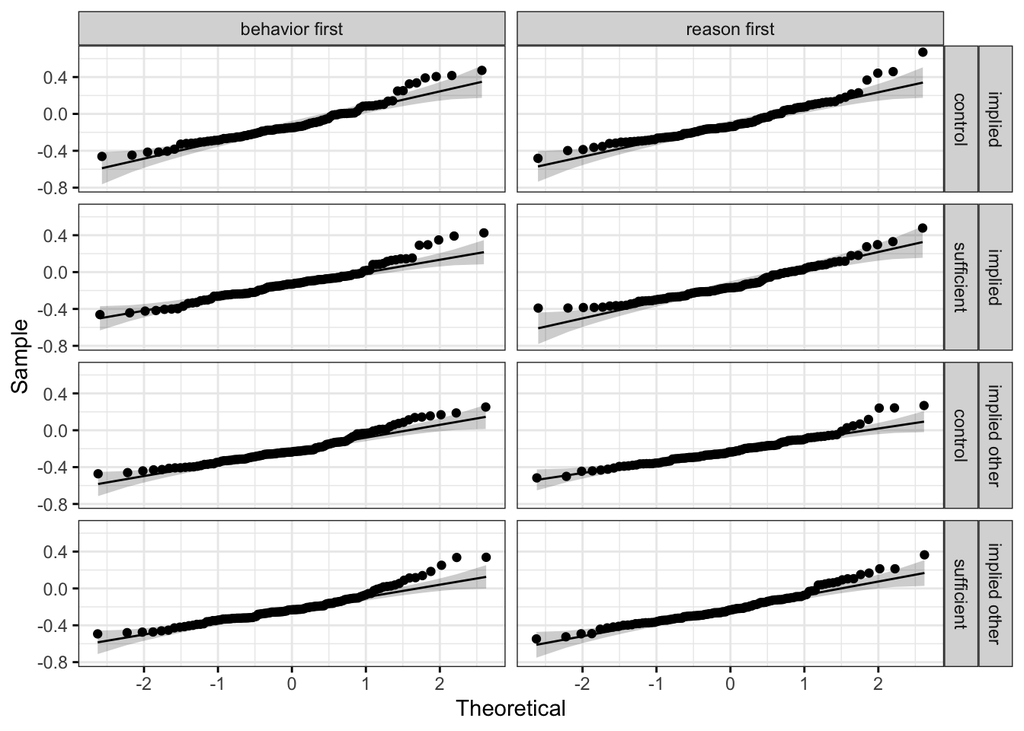

```r
# Visual inspection of normality
# Data appears slightly non-normal
ggqqplot(filter(rt_long_3f, is_extreme == FALSE),
    "rt_M2SD_log", ggtheme = theme_bw()) +
    facet_grid(probe_type ~ reason_type ~ item_order, labeller = "label_value")
```

#### ANOVA

```r
knitr::kable(m2, format = "markdown")
```

| Effect | DFn | DFd | F | p | p<.05 | pes |
| --- | --- | --- | --- | --- | --- | --- |
| probe_type | 1 | 71 | 197.7320000 | 0.000 | * | 7.36e-01 |
| reason_type | 1 | 71 | 4.0910000 | 0.047 | * | 5.40e-02 |
| item_order | 1 | 71 | 1.0740000 | 0.304 |  | 1.50e-02 |
| probe_type:reason_type | 1 | 71 | 0.6440000 | 0.425 |  | 9.00e-03 |
| probe_type:item_order | 1 | 71 | 0.0000526 | 0.994 |  | 7.00e-07 |
| reason_type:item_order | 1 | 71 | 0.0240000 | 0.876 |  | 3.44e-04 |
| probe_type:reason_type:item_order | 1 | 71 | 2.2620000 | 0.137 |  | 3.10e-02 |

#### Descriptives

```r
# Descriptives
desc_3f_by_item_order <- rt_long_3f %>%
    group_by(item_order, reason_type, probe_type) %>%
    get_summary_stats(rt_M2SD_none, type = "mean_sd")
desc_3f_by_reason_type <- rt_long_3f %>%
    group_by(reason_type, item_order, probe_type) %>%
    get_summary_stats(rt_M2SD_none, type = "mean_sd")

knitr::kable(desc_3f_by_item_order, format = "markdown")
```

| probe_type | reason_type | item_order | variable | n | mean | sd |
| --- | --- | --- | --- | --- | --- | --- |
| implied | control | behavior first | rt_M2SD_none | 98 | 0.932 | 0.209 |
| implied other | control | behavior first | rt_M2SD_none | 115 | 0.850 | 0.172 |
| implied | sufficient | behavior first | rt_M2SD_none | 106 | 0.917 | 0.181 |
| implied other | sufficient | behavior first | rt_M2SD_none | 116 | 0.838 | 0.167 |
| implied | control | reason first | rt_M2SD_none | 108 | 0.942 | 0.213 |
| implied other | control | reason first | rt_M2SD_none | 113 | 0.824 | 0.133 |
| implied | sufficient | reason first | rt_M2SD_none | 107 | 0.902 | 0.182 |
| implied other | sufficient | reason first | rt_M2SD_none | 115 | 0.836 | 0.159 |

```r
knitr::kable(desc_3f_by_reason_type, format = "markdown")
```

| probe_type | reason_type | item_order | variable | n | mean | sd |
| --- | --- | --- | --- | --- | --- | --- |
| implied | control | behavior first | rt_M2SD_none | 98 | 0.932 | 0.209 |
| implied other | control | behavior first | rt_M2SD_none | 115 | 0.850 | 0.172 |
| implied | control | reason first | rt_M2SD_none | 108 | 0.942 | 0.213 |
| implied other | control | reason first | rt_M2SD_none | 113 | 0.824 | 0.133 |
| implied | sufficient | behavior first | rt_M2SD_none | 106 | 0.917 | 0.181 |
| implied other | sufficient | behavior first | rt_M2SD_none | 116 | 0.838 | 0.167 |
| implied | sufficient | reason first | rt_M2SD_none | 107 | 0.902 | 0.182 |
| implied other | sufficient | reason first | rt_M2SD_none | 115 | 0.836 | 0.159 |

#### Visualization

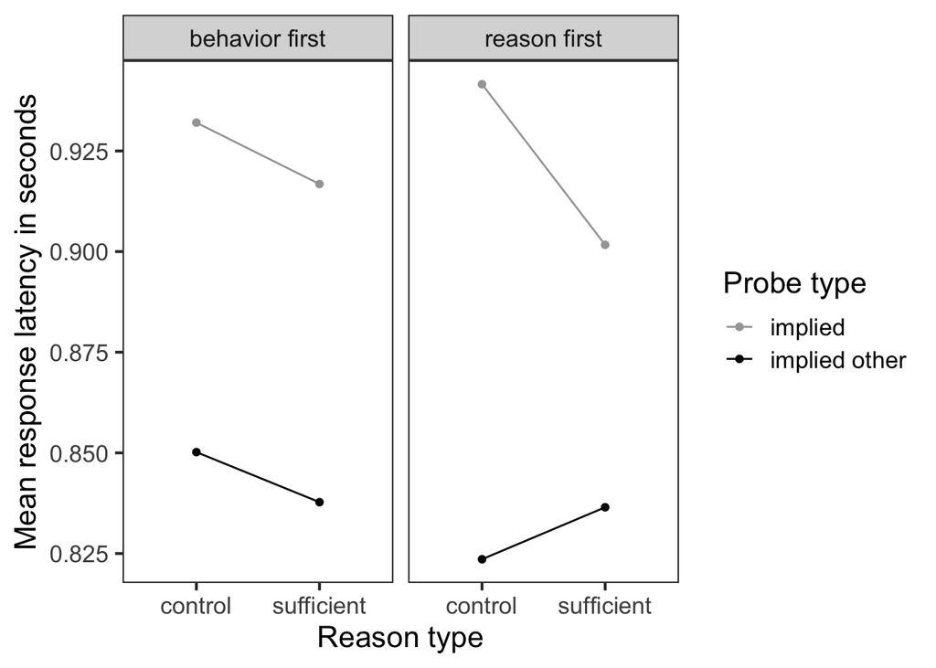

```r
rt_long_3f %>%
    ggplot(aes(reason_type, rt_M2SD_none, color = probe_type, group = probe_type)) + # nolint
    facet_wrap(. ~ item_order, labeller = "label_value") +
    labs(x = "Reason type", y = "Mean response latency in seconds", color = "Probe type") + # nolint
    scale_color_manual(values = c("#a5a5a5", "#000000")) + # nolint
    stat_summary(fun = mean, geom = "point") +
    stat_summary(fun = mean, geom = "line") +
    theme_bw(base_size = 16) +
    theme(panel.grid.major = element_blank(), panel.grid.minor = element_blank()) # nolint
```

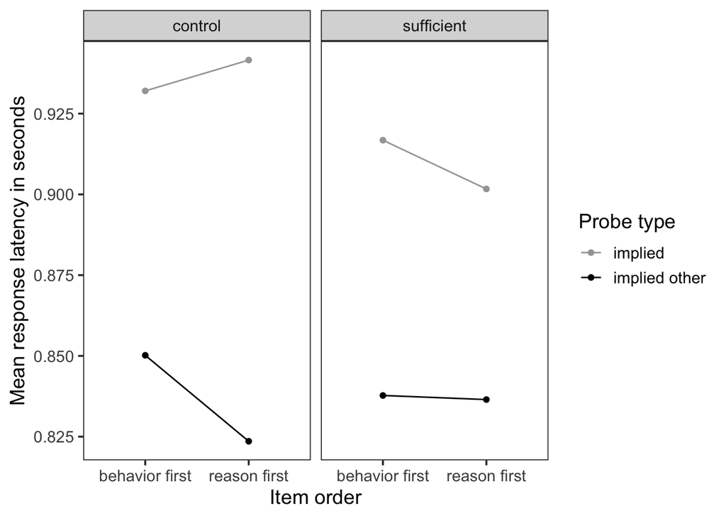

```r
rt_long_3f %>%
    ggplot(aes(item_order, rt_M2SD_none, color = probe_type, group = probe_type)) + # nolint
    facet_wrap(. ~ reason_type, labeller = "label_value") +
    labs(x = "Item order", y = "Mean response latency in seconds", color = "Probe type") + # nolint
    scale_color_manual(values = c("#a5a5a5", "#000000")) + # nolint
    stat_summary(fun = mean, geom = "point") +
    stat_summary(fun = mean, geom = "line") +
    theme_bw(base_size = 14) +
    theme(panel.grid.major = element_blank(), panel.grid.minor = element_blank()) # nolint
```

#### Post-hoc tests

```r
rt_p2_by_item_order <- rt_long_3f %>%
    filter(is_extreme == FALSE) %>%
    group_by(item_order) %>%
    anova_test(
        dv = rt_M2SD_log, wid = subject_id, effect.size = "pes",
        within = c(probe_type, reason_type))
rt_p2_by_reason_type <- rt_long_3f %>%
    filter(is_extreme == FALSE) %>%
    group_by(reason_type) %>%
    anova_test(
        dv = rt_M2SD_log, wid = subject_id, effect.size = "pes",
        within = c(probe_type, item_order))

knitr::kable(rt_p2_by_item_order, format = "markdown")
```

| item_order | Effect | DFn | DFd | F | p | p<.05 | pes |
| --- | --- | --- | --- | --- | --- | --- | --- |
| behavior first | probe_type | 1 | 85 | 131.567 | 0.000 | * | 0.608 |
| behavior first | reason_type | 1 | 85 | 1.239 | 0.269 |  | 0.014 |
| behavior first | probe_type:reason_type | 1 | 85 | 0.580 | 0.448 |  | 0.007 |
| reason first | probe_type | 1 | 93 | 113.036 | 0.000 | * | 0.549 |
| reason first | reason_type | 1 | 93 | 2.434 | 0.122 |  | 0.026 |
| reason first | probe_type:reason_type | 1 | 93 | 6.648 | 0.011 | * | 0.067 |

```r
knitr::kable(rt_p2_by_reason_type, format = "markdown")
```

| reason_type | Effect | DFn | DFd | F | p | p<.05 | pes |
| --- | --- | --- | --- | --- | --- | --- | --- |
| control | probe_type | 1 | 84 | 110.540 | 0.000 | * | 0.568 |
| control | item_order | 1 | 84 | 0.979 | 0.325 |  | 0.012 |
| control | probe_type:item_order | 1 | 84 | 1.582 | 0.212 |  | 0.018 |
| sufficient | probe_type | 1 | 95 | 156.309 | 0.000 | * | 0.622 |
| sufficient | item_order | 1 | 95 | 2.614 | 0.109 |  | 0.027 |
| sufficient | probe_type:item_order | 1 | 95 | 1.746 | 0.189 |  | 0.018 |

### Exploratory by-item analyses

#### Correlation matrix

```r
# Calculate discounting effect for each item and
# predict by identity, necessity, baserate and sufficiency
item_rate <- d_long %>%
    select(
        item_id,
        identity = rating_identity,
        necessity = rating_necessity,
        baserate = rating_baserate) %>%
    group_by(item_id) %>%
    summarize(across(c(identity, necessity, baserate), ~mean(.x, na.rm = TRUE))) %>% # nolint
    ungroup()
item_suff <- d_long %>%
    select(item_id, reason_type, rating_sufficiency) %>%
    group_by(item_id, reason_type) %>%
    summarize(across(rating_sufficiency, ~mean(.x, na.rm = TRUE))) %>%
    ungroup() %>%
    pivot_wider(
        names_from = reason_type,
        values_from = rating_sufficiency,
        names_sep = "_") %>%
    mutate(sufficiency = suff - ctrl) %>%
    select(item_id, sufficiency)
item <- d_long %>%
    filter(is_correct == 1) %>%
    select(item_id, behavior, probe_type, reason_type, rt_M2SD_log, rt_M2SD_none) %>% # nolint
    group_by(item_id, behavior, probe_type, reason_type) %>%
    summarize(across(matches("rt_"), ~mean(.x, na.rm = TRUE))) %>%
    ungroup() %>%
    pivot_wider(
        names_from = c(probe_type, reason_type),
        values_from = c(matches("rt_")),
        names_sep = "_") %>%
    # Negative Discounting values indicate reduced SII-effects
    # if sufficient compared to control reasons were provided
    mutate(
        sii_suff_M2SD_log = rt_M2SD_log_im_suff - rt_M2SD_log_io_suff,
        sii_suff_M2SD_none = rt_M2SD_none_im_suff - rt_M2SD_none_io_suff,
        sii_ctrl_M2SD_log = rt_M2SD_log_im_ctrl - rt_M2SD_log_io_ctrl,
        sii_ctrl_M2SD_none = rt_M2SD_none_im_ctrl - rt_M2SD_none_io_ctrl) %>%
    mutate(
        disc_M2SD_log = sii_suff_M2SD_log - sii_ctrl_M2SD_log,
        disc_M2SD_none = sii_suff_M2SD_none - sii_ctrl_M2SD_none) %>%
    select(-starts_with("rt_")) %>%
    left_join(item_rate) %>%
    left_join(item_suff)

c1 <- cor_table(select(item, disc_M2SD_log, identity, necessity, baserate, sufficiency)) # nolint
knitr::kable(c1, format = "markdown")
```

|  | disc_M2SD_log | identity | necessity | baserate |
| --- | --- | --- | --- | --- |
| disc_M2SD_log |  |  |  |  |
| identity | -0.16 |  |  |  |
| necessity | -0.03 | -0.35 |  |  |
| baserate | -0.34 | 0.77**** | -0.22 |  |
| sufficiency | -0.24 | 0.05 | -0.39 | 0.17 |

#### Scatter plot

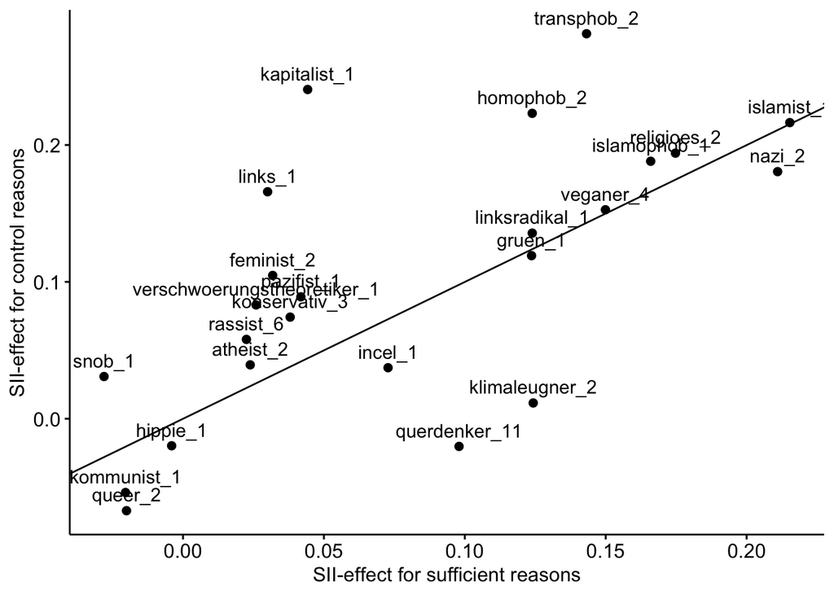

```r
ggscatter(
    item,
    "sii_suff_M2SD_none",
    "sii_ctrl_M2SD_none",
    label = "item_id",
    xlab = "SII-effect for sufficient reasons",
    ylab = "SII-effect for control reasons") +
    geom_abline(intercept = 0, slope = 1)
```

### Exploratory moderation analyses

```r
# By using multilevel models
d_mlm <- d_long %>%
    # Set RTs of incorrect responses to NA
    mutate(across(starts_with("rt_"), ~ifelse(is_correct == 0, NA, .))) %>%
    select(
        subject_id, item_id, probe_type, reason_type,
        rt_M2SD_none, starts_with("rating_"),
        age, gender, starts_with("pol_")) %>%
    pivot_wider(
        names_from = probe_type,
        values_from = c(matches("rt_|rating")),
        names_sep = "_") %>%
    mutate(
        rt_diff = rt_M2SD_none_im - rt_M2SD_none_io,
        gender = na_if(gender, "other"),
        # Grand mean center level 2 predictors
        age = age - mean(age),
        pol_orientation = pol_orientation - mean(pol_orientation),
        pol_interest = pol_interest - mean(pol_interest),
        pol_satisfaction = pol_satisfaction - mean(pol_satisfaction)
    ) %>%
    group_by(subject_id) %>%
    mutate(
        # Group mean center level 1 predictors
        identity = rating_identity_im - mean(rating_identity_im),
        necessity = rating_necessity_im - mean(rating_necessity_im),
        baserate = rating_baserate_im - mean(rating_baserate_im),
        sufficiency = rating_sufficiency_im - mean(rating_sufficiency_im),
    ) %>%
    ungroup() %>%
    select(-matches("rating_|rt_M2SD"))

# Intercept only model to check whether multilevel analysis is necessary
lm1 <- lm(rt_diff ~ 1, data = d_mlm)
mlm1 <- lmerTest::lmer(rt_diff ~ 1 + (1 | subject_id), data = d_mlm)
mlm1_var <- as.data.frame(VarCorr(mlm1))
mlm1_compare <- anova(mlm1, lm1)
# Get values for reporting
mlm1_compare_p <- ifelse(mlm1_compare[2, "Pr(>Chisq)"] < 0.001, "p < .001",
    paste("p =", sub("0.", ".", round(mlm1_compare[2, "Pr(>Chisq)"], 3))))
mlm1_delta_r2 <- round(mlm1_var$vcov[1] / sum(mlm1_var$vcov) * 100, 2)

# Run multilevel model with ratings
mlm2 <- lmerTest::lmer(rt_diff ~ identity + necessity + sufficiency + baserate +
                       (1 | subject_id), data = d_mlm)
mlm2_var <- as.data.frame(VarCorr(mlm2))
# Calculate increases in R-squared
mlm2_delta_r2_lvl1 <- round((mlm1_var[2, 4] - mlm2_var[2, 4]) / mlm1_var[2, 4] * 100, 2) # nolint
mlm2_delta_r2_lvl2 <- round((mlm1_var[1, 4] - mlm2_var[1, 4]) / mlm1_var[1, 4] * 100, 2) # nolint
# Compare model fit
# anova(mlm2, mlm1)
# Calculate effect size for identity rating
coef <- summary(mlm2)$coefficients
coef_identity <- abs(round(coef[rownames(coef) == "identity", "Estimate"] * 1000, 2)) # nolint
coef_necessity <- abs(round(coef[rownames(coef) == "necessity", "Estimate"] * 1000, 2)) # nolint
coef_baserate <- abs(round(coef[rownames(coef) == "baserate", "Estimate"] * 1000, 2)) # nolint

# Run multilevel model with level 2 predictors
mlm3 <- lmerTest::lmer(rt_diff ~ identity + necessity + sufficiency + baserate +
                       pol_orientation + pol_interest + pol_satisfaction +
                       (1 | subject_id), data = d_mlm)
mlm3_var <- as.data.frame(VarCorr(mlm3))
# Calculate increases in R-squared
mlm3_delta_r2_lvl2 <- round((mlm2_var[1, 4] - mlm3_var[1, 4]) / mlm2_var[1, 4] * 100, 2) # nolint
# Compare model fit
# anova(mlm3, mlm2)
```

We performed exploratory moderation analyses to investigate whether the ratings regarding the baserate and necessity of the labels as well as the identification with the labels and the sufficiency of the reasons could explain the strength of the SII-effect. We used a difference score (implied minus implied other) of the reaction times (using an individual mean plus two standard deviations cut-off for slow responses and no transformation) as the dependent variable. To test whether a multilevel modelling approach was necessary we built an intercept only model and tested whether a random effect for the participants significantly increased the model fit. The random intercept model fit the data significantly better, $\chi^2$(1, 2) = 35.91, p < .001 (even though the variance explained by the random effect was only 5.01 %). We thus fitted a multilevel model. The data was assigned to two levels – the reaction time difference level (level 1) and the participant level (level 2). As independent variables at level 1 we used the ratings of identity, necessity, baserate, and sufficiency. All ratings were centered using the individual participant mean rather than the grand mean. The reasoning behind this was that participants might have different response tendencies such that the relative rating would be a better predictor than the absolute values. Moreover, in a second step we added the participants’ political orientation, political interest and satisfaction with the German political system as independent variables at level 2 (participant level).

Model I contained only the level 1 predictors. Of the four ratings the extent to which participants identified with the labels, the necessity of the label to explain the behavior as well as the baserate of the label predicted the size of the SII-effect. An increase of one scale point in the identity ratings (on a five point scale) was associated with a decrease of 14.62 ms in the SII-effect. This indicates that participants more strongly inferred labels the less they identified with them. An increase of one scale point in the necessity ratings (on a five point scale) was associated with an increase of 19.55 ms in the SII-effect. This indicates that participants more strongly inferred labels when they thought they were necessary to explain the behaviors. An increase of one scale point in the baserate ratings (on a five point scale) was associated with an increase of 16.1 ms in the SII-effect. This indicates that participants more strongly inferred labels that they deemed likely to apply to a stranger. The sufficiency rating had no significant effect. Together the four ratings explained 1.5 % of the variance on level 1 and -0.58 % of the variance on level 2.

Model II contained the level 1 and level 2 predictors. Of the seven predictors still only identification, necessity, and baserate were significantly associated with the SII-effect. Together the seven predictors explained -3.68 % of the variance on level 2.

#### Results Model I

```r
sjPlot::tab_model(mlm2)
```

|  | rt_diff |  |  |
| --- | --- | --- | --- |
| Predictors | Estimates | CI | p |
| (Intercept) | 0.09 | 0.07 – 0.10 | **<0.001** |
| identity | -0.01 | -0.02 – -0.01 | **0.003** |
| necessity | 0.02 | 0.01 – 0.03 | **<0.001** |
| sufficiency | -0.01 | -0.01 – 0.00 | 0.141 |
| baserate | 0.02 | 0.00 – 0.03 | **0.010** |
| Random Effects |  |  |  |
| σ<sup>2</sup> | 0.07 |  |  |
| τ<sub>00</sub> <sub>subject_id</sub> | 0.00 |  |  |
| ICC | 0.05 |  |  |
| N <sub>subject_id</sub> | 118 |  |  |
| Observations | 2319 |  |  |
| Marginal R<sup>2</sup> / Conditional R<sup>2</sup> | 0.015 / 0.066 |  |  |

#### Results Model II

```r
sjPlot::tab_model(mlm3)
```

|  | rt_diff |  |  |
| --- | --- | --- | --- |
| Predictors | Estimates | CI | p |
| (Intercept) | 0.09 | 0.07 – 0.10 | **<0.001** |
| identity | -0.01 | -0.02 – -0.01 | **0.003** |
| necessity | 0.02 | 0.01 – 0.03 | **<0.001** |
| sufficiency | -0.01 | -0.01 – 0.00 | 0.141 |
| baserate | 0.02 | 0.00 – 0.03 | **0.010** |
| pol orientation | 0.00 | -0.01 – 0.02 | 0.461 |
| pol interest | 0.00 | -0.01 – 0.01 | 0.849 |
| pol satisfaction | 0.01 | -0.03 – 0.04 | 0.733 |
| Random Effects |  |  |  |
| σ<sup>2</sup> | 0.07 |  |  |
| τ<sub>00</sub> <sub>subject_id</sub> | 0.00 |  |  |
| ICC | 0.05 |  |  |
| N <sub>subject_id</sub> | 118 |  |  |
| Observations | 2319 |  |  |
| Marginal R<sup>2</sup> / Conditional R<sup>2</sup> | 0.016 / 0.068 |  |  |

#### Visualization identity

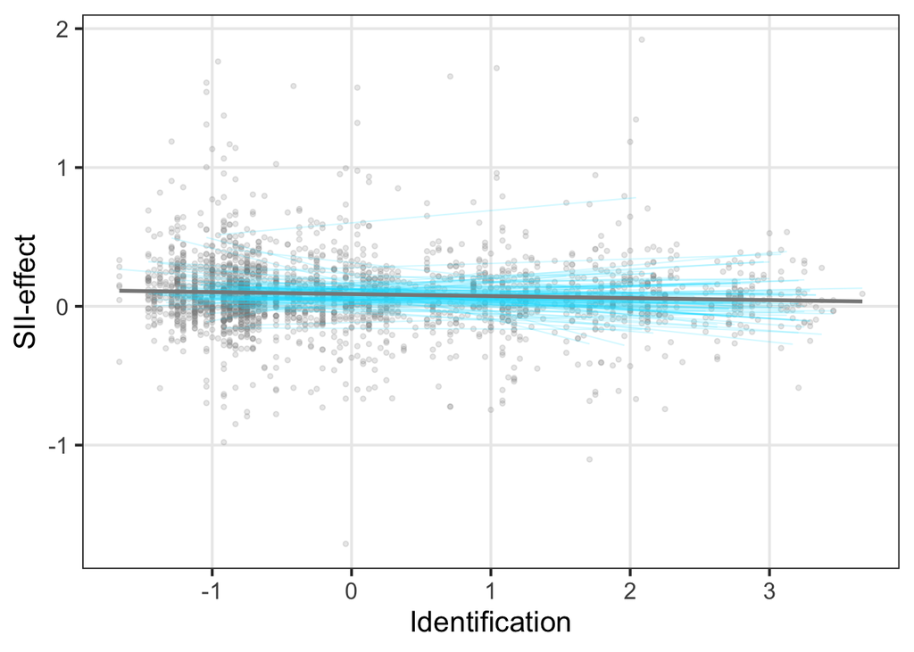

```r
d_mlm %>% ggplot(aes(x = identity, y = rt_diff, group = subject_id)) +
    geom_point(size = 1, col = "#88888830") +
    labs(y = "SII-effect", x = "Identification") +
    geom_smooth(method = "lm", se = FALSE, color = "#00e1ff30", size = 0.4) + # nolint
    geom_smooth(method = "lm", se = FALSE, color = "#888888", aes(identity, rt_diff, group = NA)) +
    theme_bw(base_size = 16) +
    theme(legend.position = "none", panel.grid.minor = element_blank())
```

#### Visualization necessity

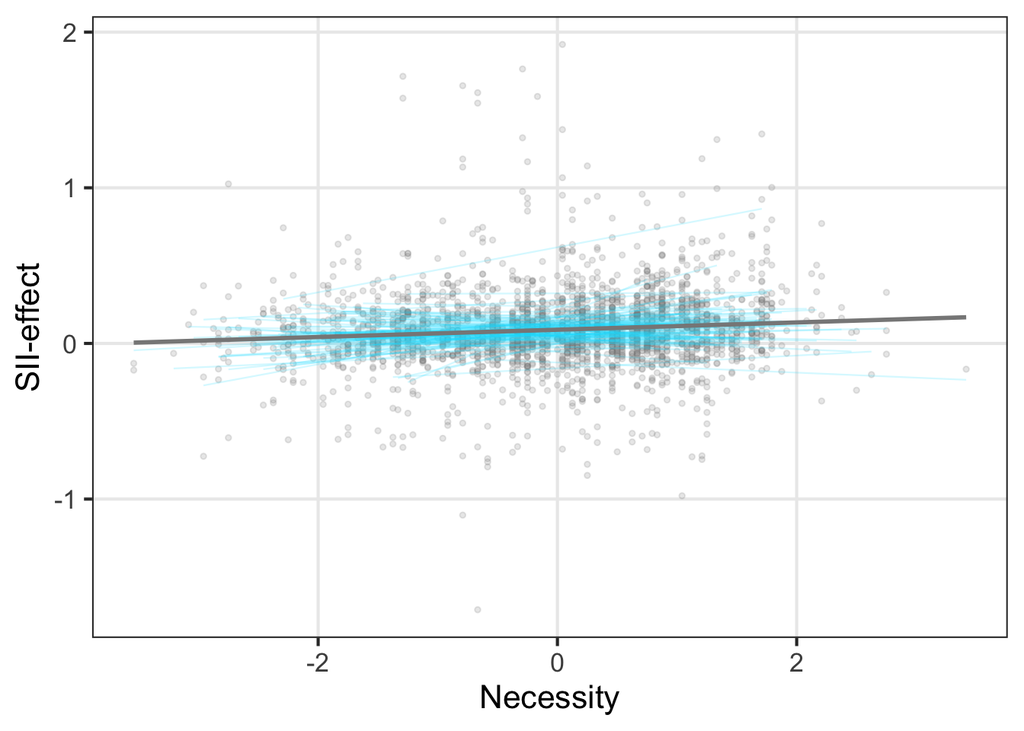

```r
d_mlm %>% ggplot(aes(x = necessity, y = rt_diff, group = subject_id)) +
    geom_point(size = 1, col = "#88888830") +
    labs(y = "SII-effect", x = "Necessity") +
    geom_smooth(method = "lm", se = FALSE, color = "#00e1ff30", size = 0.4) + # nolint
    geom_smooth(method = "lm", se = FALSE, color = "#888888", aes(necessity, rt_diff, group = NA)) +
    theme_bw(base_size = 16) +
    theme(legend.position = "none", panel.grid.minor = element_blank())
```

#### Visualization baserate

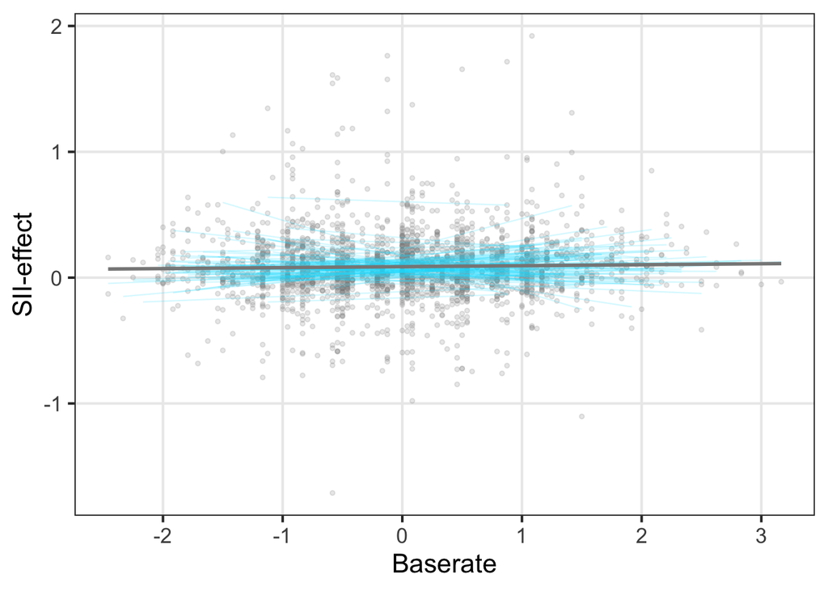

```r
d_mlm %>% ggplot(aes(x = baserate, y = rt_diff, group = subject_id)) +
    geom_point(size = 1, col = "#88888830") +
    labs(y = "SII-effect", x = "Baserate") +
    geom_smooth(method = "lm", se = FALSE, color = "#00e1ff30", size = 0.4) + # nolint
    geom_smooth(method = "lm", se = FALSE, color = "#888888", aes(baserate, rt_diff, group = NA)) +
    theme_bw(base_size = 16) +
    theme(legend.position = "none", panel.grid.minor = element_blank())
```